# Analysis and Prediction of Employee Attrition.

```r
length(emp_df$NumCompaniesWorked[emp_df$NumCompaniesWorked==9])
```

```
## [1] 52
```

There are total of 52 records with Number of Companies Worked as 9. Droping this record may not be a wise choice. They need to be transformed.

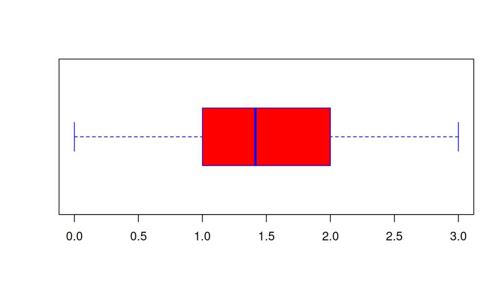

```r
boxplot(sqrt(emp_df$NumCompaniesWorked),range=1.5,col=c("red"),border=c("blue"),horizontal = TRUE)
```

For Percentage Salary Hike

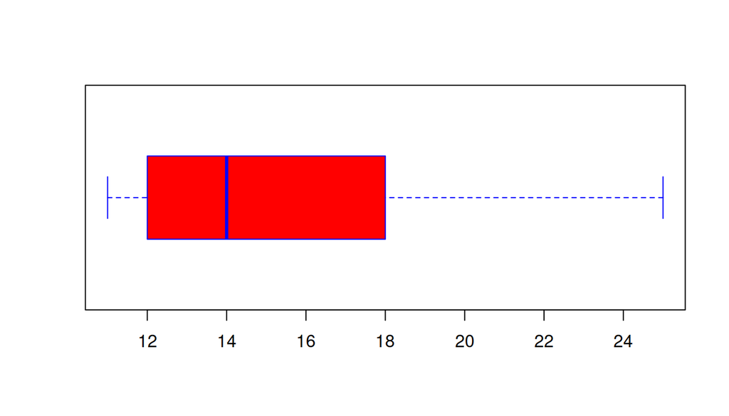

```r
boxplot(emp_df$PercentSalaryHike,range=1.5,col=c("red"),border=c("blue"),horizontal = TRUE)
```

For Total Working Years

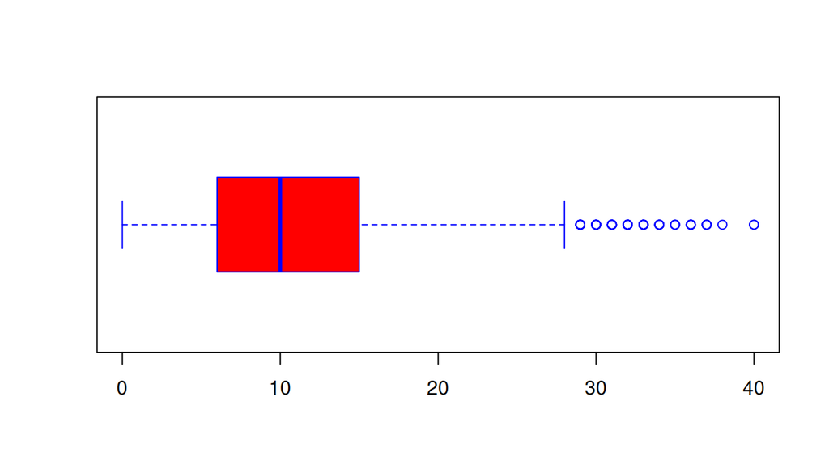

```r
boxplot(emp_df$TotalWorkingYears,range=1.5,col=c("red"),border=c("blue"),horizontal = TRUE)
```

The distribution of number of total working years

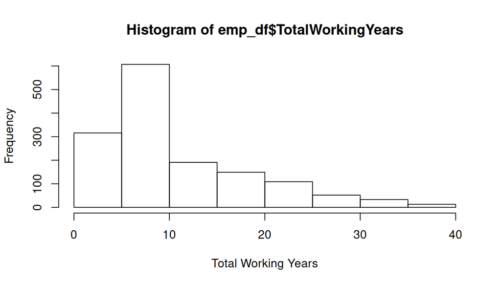

```r
hist(emp_df$TotalWorkingYears,xlab="Total Working Years")
```

Applying Square root transformation

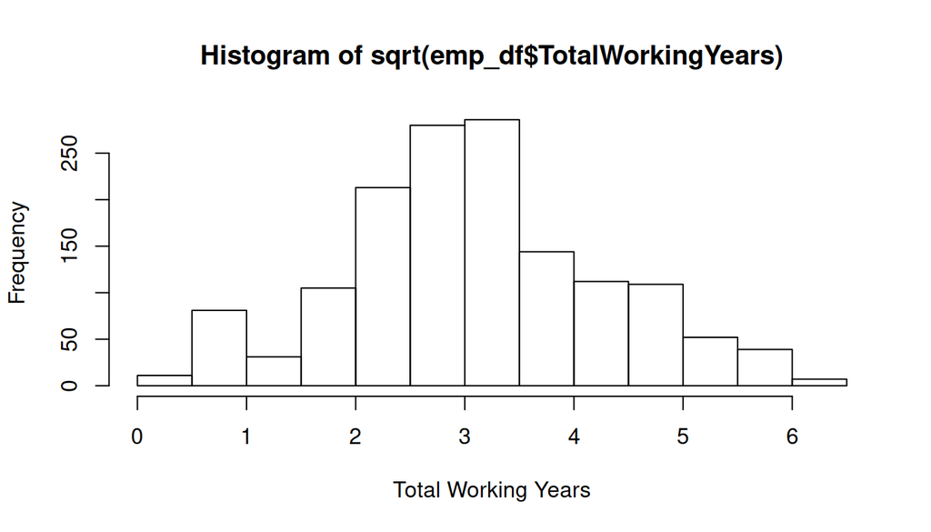

```r
hist(sqrt(emp_df$TotalWorkingYears) ,xlab="Total Working Years")
```

Squart Root Tranformation seems to convert the data into a normal distribution which removes the ouliers.

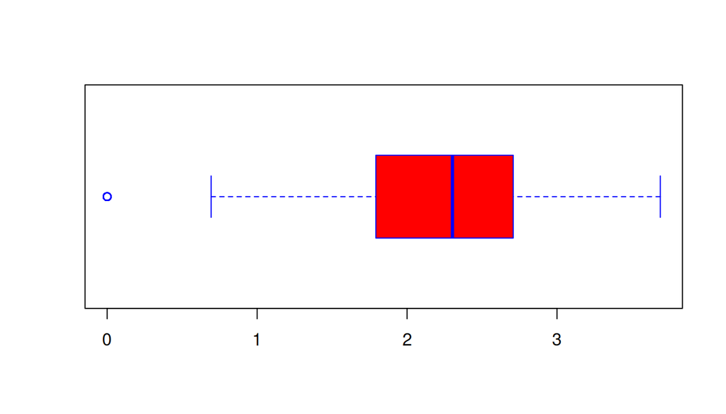

```r
boxplot(log(emp_df$TotalWorkingYears),range=1.5,col=c("red"),border=c("blue"),horizontal = TRUE)
```

Yet to Conclude. For Years At Company

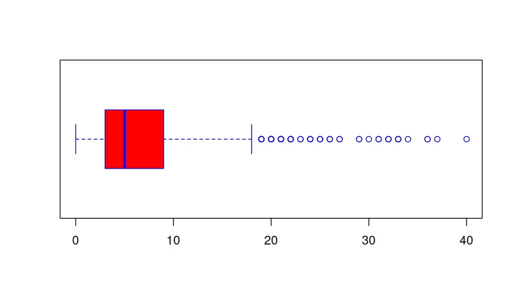

```r
boxplot(emp_df$YearsAtCompany,range=1.5,col=c("red"),border=c("blue"),horizontal = TRUE)
```

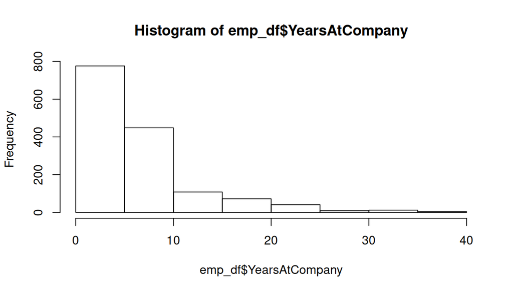

```r
hist(emp_df$YearsAtCompany)
```

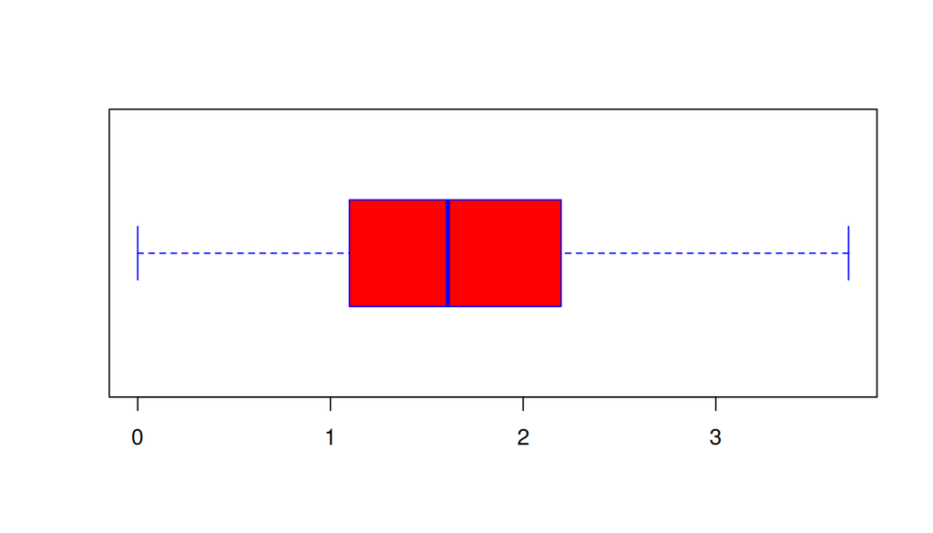

```r
boxplot(log(emp_df$YearsAtCompany),range=1.5,col=c("red"),border=c("blue"),horizontal = TRUE)
```

For Years in current role

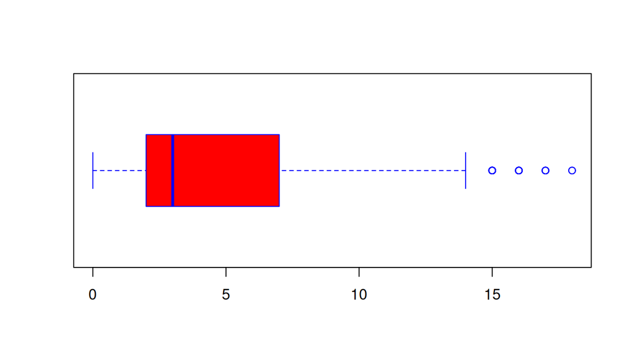

```r
boxplot(emp_df$YearsInCurrentRole,range=1.5,col=c("red"),border=c("blue"),horizontal = TRUE)
```

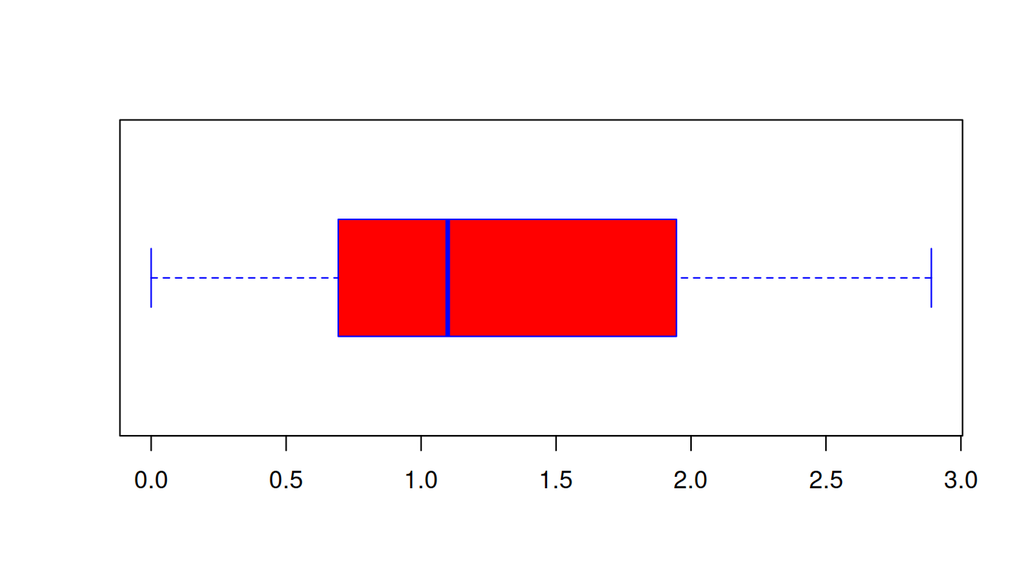

```r
boxplot(log(emp_df$YearsInCurrentRole),range=1.5,col=c("red"),border=c("blue"),horizontal = TRUE)
```

For Years Since Last Promotion

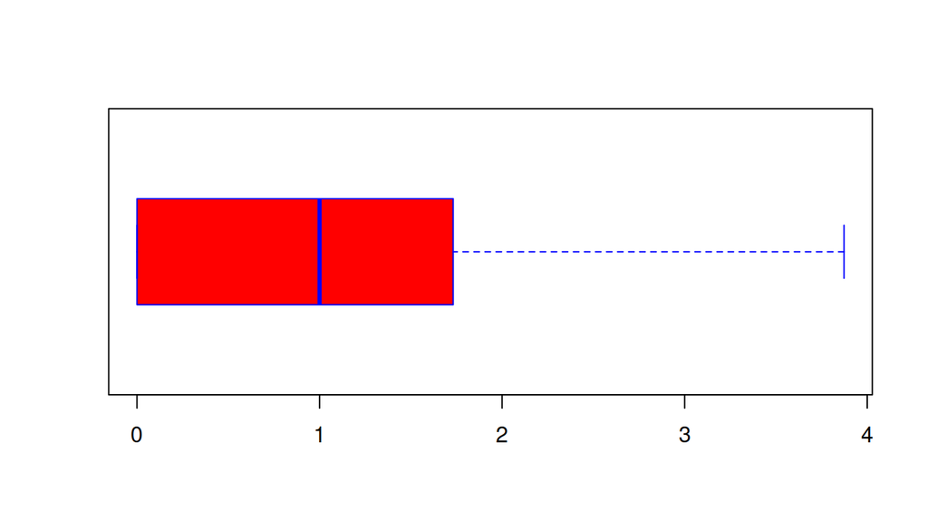

```r
boxplot(sqrt(emp_df$YearsSinceLastPromotion),range=1.5,col=c("red"),border=c("blue"),horizontal = TRUE)
```

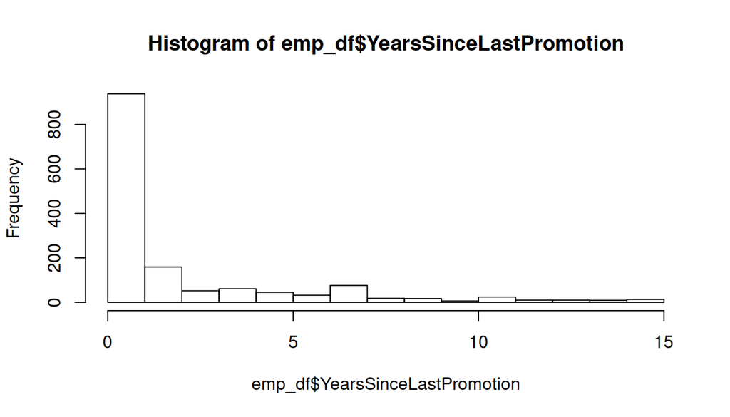

```r
hist(emp_df$YearsSinceLastPromotion)
```

```r
cor(emp_df$YearsSinceLastPromotion,emp_df$Attrition)
```

```
## [1] -0.03301878
```

For Years With Current Manager

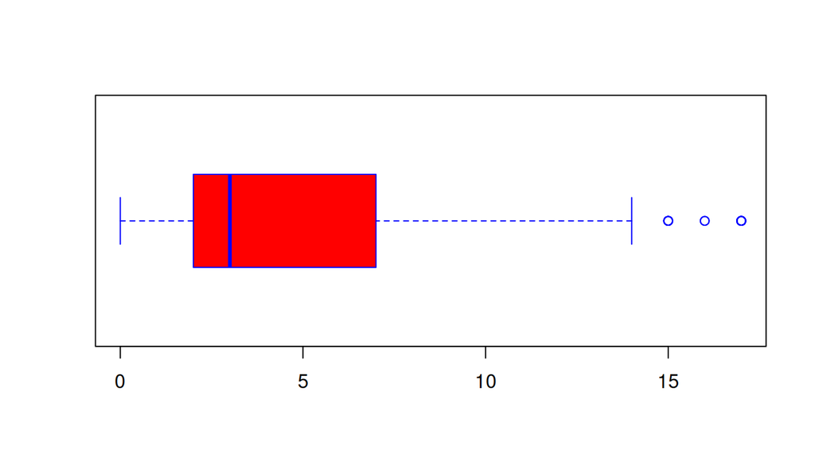

```r
boxplot(emp_df$YearsWithCurrManager,range=1.5,col=c("red"),border=c("blue"),horizontal = TRUE)
```

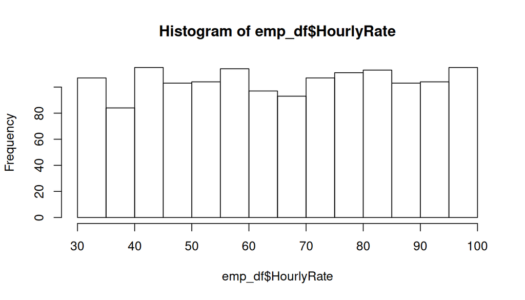

```r
hist(emp_df$HourlyRate)
```

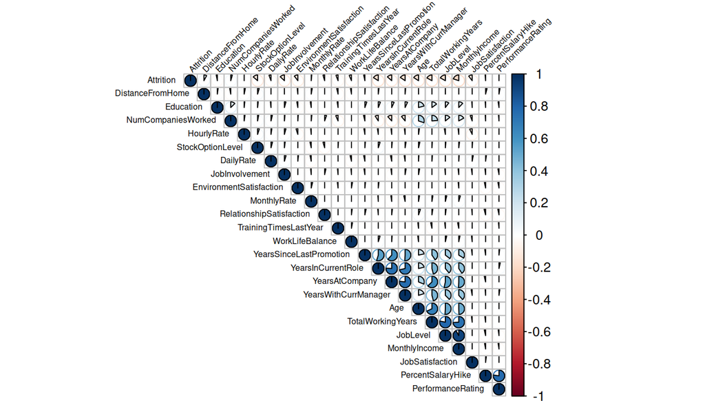

```r
library(corrplot)
corrplot(cor(select_if(emp_df,"is.numeric")),method="pie",type="upper",tl.col="black",order="hclust",tl.srt=45,tl.cex=0.5)
```

# Models

## Logistic Regression.

The categorical data must be encoded for the logistic regression model. The data tranformation are already performed earlier

```r
library(caret)
one_hot_emp_df<-dummyVars("~.",data=emp_df,fullRank=T)
one_hot_emp_df<-data.frame(predict(one_hot_emp_df,emp_df))
str(one_hot_emp_df)
```

```
## 'data.frame':    1470 obs. of  45 variables:
##  $ Age                              : num  41 49 37 33 27 32 59 30 38 36 ...
##  $ Attrition                        : num  1 0 1 0 0 0 0 0 0 0 ...
##  $ BusinessTravel.Travel_Frequently : num  0 1 0 1 0 1 0 0 1 0 ...
##  $ BusinessTravel.Travel_Rarely     : num  1 0 1 0 1 0 1 1 0 1 ...
##  $ DailyRate                        : num  1102 279 1373 1392 591 ...
##  $ Department.Research...Development: num  0 1 1 1 1 1 1 1 1 1 ...
##  $ Department.Sales                 : num  1 0 0 0 0 0 0 0 0 0 ...
##  $ DistanceFromHome                 : num  1 8 2 3 2 2 3 24 23 27 ...
##  $ Education                        : num  2 1 2 4 1 2 3 1 3 3 ...
##  $ EducationField.Life.Sciences     : num  1 1 0 1 0 1 0 1 1 0 ...
##  $ EducationField.Marketing         : num  0 0 0 0 0 0 0 0 0 0 ...
##  $ EducationField.Medical           : num  0 0 0 0 1 0 1 0 0 1 ...
##  $ EducationField.Other             : num  0 0 1 0 0 0 0 0 0 0 ...
##  $ EducationField.Technical.Degree  : num  0 0 0 0 0 0 0 0 0 0 ...
```

[output cut: 31 more lines]

Spliting the data

```r
split<-sample.int(nrow(emp_df),replace = FALSE,size=floor(0.8*nrow(emp_df)))
train_lr_data<-one_hot_emp_df[split,]
test_lr_data<-one_hot_emp_df[-split,]
```

Model Implementation

```r
lr_model<-glm(Attrition~.,train_lr_data,family = "binomial")
summary(lr_model)
```

```
##
## Call:
## glm(formula = Attrition ~ ., family = "binomial", data = train_lr_data)
##
## Deviance Residuals:
##     Min       1Q   Median       3Q      Max
## -1.9269  -0.4727  -0.2409  -0.0808   3.4367
##
## Coefficients:
##                                     Estimate Std. Error z value Pr(>|z|)
## (Intercept)                       -2.278e-01  6.886e+02   0.000 0.999736
## Age                               -2.045e-02  1.490e-02  -1.372 0.169927
## BusinessTravel.Travel_Frequently   2.060e+00  4.600e-01   4.478 7.55e-06 ***
## BusinessTravel.Travel_Rarely       1.088e+00  4.170e-01   2.609 0.009079 **
## DailyRate                         -3.746e-04  2.511e-04  -1.492 0.135686
## Department.Research...Development  1.377e+01  6.885e+02   0.020 0.984044
## Department.Sales                   1.396e+01  6.885e+02   0.020 0.983824
## DistanceFromHome                   6.140e-02  1.240e-02   4.951 7.37e-07 ***
## Education                          3.630e-03  1.007e-01   0.036 0.971252
## EducationField.Life.Sciences      -7.335e-01  1.008e+00  -0.728 0.466855
## EducationField.Marketing          -2.966e-01  1.053e+00  -0.282 0.778147
## EducationField.Medical            -1.122e+00  1.011e+00  -1.110 0.267046
## EducationField.Other              -8.655e-01  1.068e+00  -0.810 0.417774
## EducationField.Technical.Degree    1.507e-01  1.017e+00   0.148 0.882224
## EnvironmentSatisfaction           -4.781e-01  9.557e-02  -5.003 5.66e-07 ***
## Gender.Male                        2.813e-01  2.083e-01   1.350 0.176910
## HourlyRate                        -1.424e-03  5.035e-03  -0.283 0.777355
## JobInvolvement                    -5.956e-01  1.399e-01  -4.258 2.07e-05 ***
## JobLevel                           4.555e-01  3.121e-01   1.459 0.144490
## JobRole.Human.Resources            1.389e+01  6.885e+02   0.020 0.983906
## JobRole.Laboratory.Technician      4.856e-01  5.318e-01   0.913 0.361175
## JobRole.Manager                    2.937e-01  9.446e-01   0.311 0.755861
## JobRole.Manufacturing.Director     1.548e-01  5.614e-01   0.276 0.782747
## JobRole.Research.Director         -1.542e+00  1.384e+00  -1.115 0.265064
## JobRole.Research.Scientist        -4.973e-01  5.495e-01  -0.905 0.365428
## JobRole.Sales.Executive            4.842e-01  1.248e+00   0.388 0.698057
## JobRole.Sales.Representative       7.847e-01  1.310e+00   0.599 0.549066
## JobSatisfaction                   -3.604e-01  9.480e-02  -3.802 0.000144 ***
## MaritalStatus.Married              4.300e-01  3.092e-01   1.391 0.164351
## MaritalStatus.Single               1.388e+00  3.995e-01   3.474 0.000514 ***
```

[output cut: 10 more lines]

```
## WorkLifeBalance                   -4.478e-01  1.417e-01  -3.161 0.001573 **
## YearsAtCompany                     1.083e-01  4.409e-02   2.456 0.014061 *
## YearsInCurrentRole                -1.501e-01  5.165e-02  -2.906 0.003656 **
## YearsSinceLastPromotion            1.513e-01  4.757e-02   3.180 0.001475 **
## YearsWithCurrManager              -1.476e-01  5.362e-02  -2.753 0.005904 **
## ---
## Signif. codes:  0 '***' 0.001 '**' 0.01 '*' 0.05 '.' 0.1 ' ' 1
##
## (Dispersion parameter for binomial family taken to be 1)
##
##     Null deviance: 1036.88  on 1175  degrees of freedom
## Residual deviance:  665.61  on 1131  degrees of freedom
## AIC: 755.61
##
## Number of Fisher Scoring iterations: 15
```

There are a lot of features with p-value as high as 0.1. Training Accuracy (Threshold=0.5)

```r
conf_matrix<-table(train_lr_data$Attrition,predict(lr_model,train_lr_data,type="response")>0.5)
print(conf_matrix)
```

```
##
##     FALSE TRUE
##   0   969   18
##   1    94   95
```

```r
print(sum(diag(conf_matrix))/sum(conf_matrix))
```

```
## [1] 0.9047619
```

```r
library(ROCR)
roc_predcition<-prediction(predict(lr_model,test_lr_data,type="response"),test_lr_data$Attrition)
AUC<-performance(roc_predcition,measure="auc")@y.values[[1]]
print(AUC)
```

```
## [1] 0.8274898
```

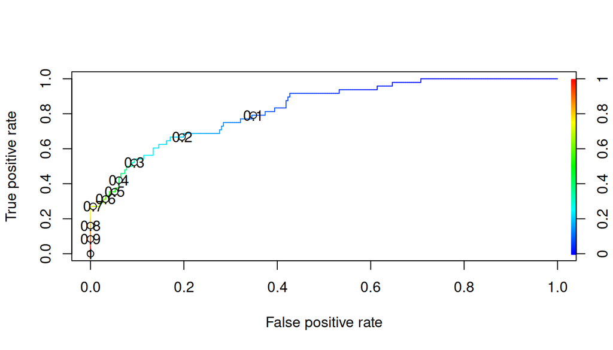

```r
roc_performace<-performance(roc_predcition,"tpr","fpr")
plot(roc_performace,colorize=1,print.cutoffs.at=seq(0.1,by=(0.1)))
```

Testing the model

```r
conf_matrix<-table(test_lr_data$Attrition,predict(lr_model,test_lr_data,type="response")>0.6)
print(conf_matrix)
```

```
##
##     FALSE TRUE
##   0   239    7
##   1    33   15
```

```r
print(sum(diag(conf_matrix))/sum(conf_matrix))
```

```
## [1] 0.8639456
```

Selected features model

```r
sf_emp_df<-select(one_hot_emp_df,-c("Department.Research...Development"
,"Department.Sales"
,"EducationField.Life.Sciences"
,"EducationField.Marketing"
,"EducationField.Medical"
,"EducationField.Other"
,"EducationField.Technical.Degree"
,"JobRole.Human.Resources"
,"JobRole.Laboratory.Technician"
,"JobRole.Manager"
,"JobRole.Manufacturing.Director"
,"JobRole.Research.Director"
,"JobRole.Research.Scientist"
,"JobRole.Sales.Executive"
,"JobRole.Sales.Representative"))
sf_train_lr_data<-sf_emp_df[split,]
sf_test_lr_data<-sf_emp_df[-split,]
sf_lr_model<-glm(Attrition~.,sf_train_lr_data,family = "binomial")
summary(sf_lr_model)
```

```
##
## Call:
## glm(formula = Attrition ~ ., family = "binomial", data = sf_train_lr_data)
##
## Deviance Residuals:
##     Min       1Q   Median       3Q      Max
## -2.0105  -0.5063  -0.2766  -0.1116   3.5984
##
## Coefficients:
##                                    Estimate Std. Error z value Pr(>|z|)
## (Intercept)                       1.228e+01  3.135e+00   3.916 8.98e-05 ***
## Age                              -1.646e-02  1.439e-02  -1.144 0.252480
## BusinessTravel.Travel_Frequently  1.980e+00  4.416e-01   4.483 7.36e-06 ***
## BusinessTravel.Travel_Rarely      1.069e+00  4.075e-01   2.623 0.008719 **
## DailyRate                        -3.500e-04  2.416e-04  -1.448 0.147507
## DistanceFromHome                  5.594e-02  1.169e-02   4.785 1.71e-06 ***
## Education                         1.081e-02  9.633e-02   0.112 0.910626
## EnvironmentSatisfaction          -4.459e-01  8.942e-02  -4.986 6.16e-07 ***
## Gender.Male                       2.523e-01  1.999e-01   1.262 0.207079
## HourlyRate                       -2.622e-03  4.849e-03  -0.541 0.588666
## JobInvolvement                   -6.379e-01  1.343e-01  -4.749 2.05e-06 ***
## JobLevel                          6.444e-01  2.649e-01   2.433 0.014994 *
## JobSatisfaction                  -3.598e-01  9.072e-02  -3.966 7.30e-05 ***
## MaritalStatus.Married             4.399e-01  2.997e-01   1.468 0.142164
## MaritalStatus.Single              1.333e+00  3.795e-01   3.512 0.000445 ***
## MonthlyIncome                    -1.349e+00  3.687e-01  -3.658 0.000254 ***
## MonthlyRate                       4.118e-07  1.357e-05   0.030 0.975788
## NumCompaniesWorked                1.822e-01  4.161e-02   4.378 1.20e-05 ***
## OverTime.Yes                      1.763e+00  2.060e-01   8.559  < 2e-16 ***
## PercentSalaryHike                -5.295e-02  4.307e-02  -1.230 0.218851
## PerformanceRating                 4.221e-01  4.448e-01   0.949 0.342718
## RelationshipSatisfaction         -2.214e-01  8.968e-02  -2.469 0.013568 *
## StockOptionLevel                 -1.528e-01  1.660e-01  -0.921 0.357303
## TotalWorkingYears                -9.879e-02  3.190e-02  -3.097 0.001958 **
## TrainingTimesLastYear            -2.037e-01  7.928e-02  -2.569 0.010186 *
## WorkLifeBalance                  -3.723e-01  1.345e-01  -2.769 0.005624 **
## YearsAtCompany                    8.372e-02  4.221e-02   1.984 0.047304 *
## YearsInCurrentRole               -1.264e-01  4.964e-02  -2.546 0.010906 *
## YearsSinceLastPromotion           1.483e-01  4.518e-02   3.282 0.001029 **
## YearsWithCurrManager             -1.263e-01  5.089e-02  -2.482 0.013075 *
## ---
## Signif. codes:  0 '***' 0.001 '**' 0.01 '*' 0.05 '.' 0.1 ' ' 1
##
## (Dispersion parameter for binomial family taken to be 1)
##
##     Null deviance: 1036.88  on 1175  degrees of freedom
## Residual deviance:  712.06  on 1146  degrees of freedom
## AIC: 772.06
##
## Number of Fisher Scoring iterations: 6
```

```r
sf_conf_matrix<-table(sf_test_lr_data$Attrition,predict(sf_lr_model,sf_test_lr_data,type="response")>0.5)
print(sf_conf_matrix)
```

```
##
##     FALSE TRUE
##   0   235   11
##   1    33   15
```

```r
print(sum(diag(sf_conf_matrix))/sum(sf_conf_matrix))
```

```
## [1] 0.8503401
```

There is no significant difference between the two models. Training time may reduce. Feature Importance.

```r
coeff<-summary(lr_model)$coefficients
coeff<-data.frame(coeff[,0],coeff[,1])
coeff<-tibble::rownames_to_column(coeff,"term")
names(coeff)<-c("Coefficient","Estimate")
rownames(coeff)<-coeff$Coefficient
coeff<-subset(coeff,!(row.names(coeff) %in%c("Department.Research...Development"
,"Department.Sales"
,"EducationField.Life.Sciences"
,"EducationField.Marketing"
,"EducationField.Medical"
,"EducationField.Other"
,"EducationField.Technical.Degree"
,"JobRole.Human.Resources"
,"JobRole.Laboratory.Technician"
,"JobRole.Manager"
,"JobRole.Manufacturing.Director"
,"JobRole.Research.Director"
,"JobRole.Research.Scientist"
,"JobRole.Sales.Executive"
,"JobRole.Sales.Representative","(Intercept)","MaritalStatus.Single","MaritalStatus.Married","DailyRate"
,"Gender.Male"
,"MonthlyRate","HourlyRate","BusinessTravel.Travel_Frequently","BusinessTravel.Travel_Rarely")))
```

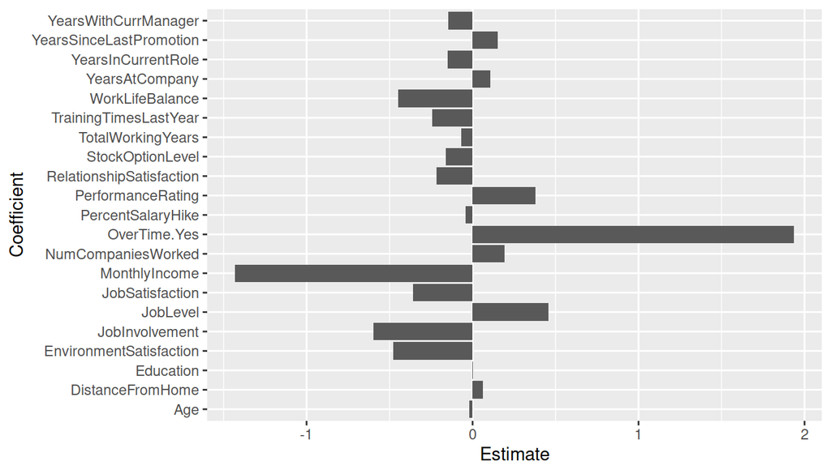

```r
ggplot(coeff,aes(Coefficient,Estimate))+geom_bar(stat="identity")+coord_flip()
```

From the Logistic Regression Model, Over Time is identified as the most contributing factor to Employee Attrition. Monthly Income is the most weighted negative factor, so a higher monthly income can reduce employee attrition. Job Involvement, Environment Satisfaction and Work LIfe Balance Seems to a have positive effect on reducing employee attrition.

# Decision Tree.

```r
split<-sample.int(nrow(emp_df),size=floor(0.8*nrow(emp_df)),replace=FALSE)
train_dt_data<-emp_df[split,]
test_dt_data<-emp_df[-split,]
```

```r
library(party)
```

[figure not shown]

```r
dt_model<-ctree(Attrition~.,train_dt_data)
plot(dt_model)
```

Training Accuracy (Threshold=0.5)

```r
conf_matrix<-table(train_dt_data$Attrition,predict(dt_model,train_dt_data,type="response")>0.5)
print(conf_matrix)
```

```
##
##     FALSE TRUE
##   0   947   44
##   1   110   75
```

```r
print(sum(diag(conf_matrix))/sum(conf_matrix))
```

```
## [1] 0.8690476
```

```r
library(ROCR)
roc_predcition<-prediction(predict(dt_model,test_dt_data,type="response"),test_dt_data$Attrition)
AUC<-performance(roc_predcition,measure="auc")@y.values[[1]]
print(AUC)
```

```
## [1] 0.7325175
```

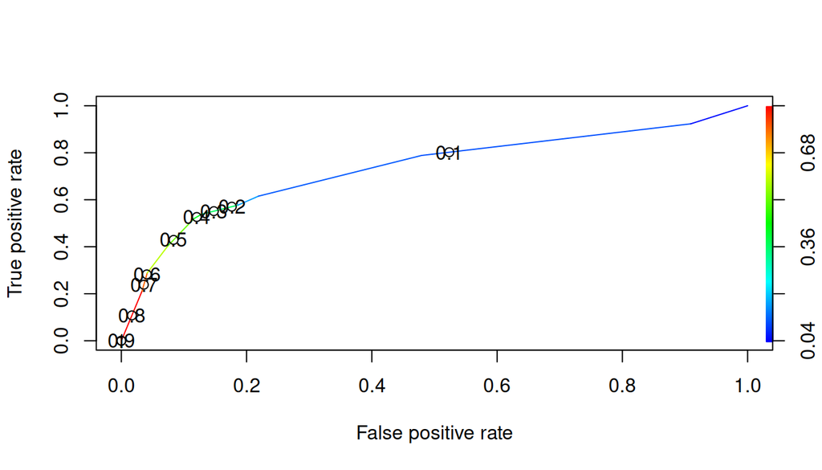

```r
roc_performace<-performance(roc_predcition,"tpr","fpr")
plot(roc_performace,colorize=1,print.cutoffs.at=seq(0.1,by=(0.1)))
```

Testing Accuracy (Threshold=0.5)

```r
conf_matrix<-table(test_dt_data$Attrition,predict(dt_model,test_dt_data,type="response")>0.5)
print(conf_matrix)
```

```
##
##     FALSE TRUE
##   0   224   18
##   1    31   21
```

```r
print(sum(diag(conf_matrix))/sum(conf_matrix))
```

```
## [1] 0.8333333
```

```r
summary(dt_model)
```

```
##     Length      Class       Mode
##          1 BinaryTree         S4
```